# Peer-graded Assignment: Prediction Assignment Writeup

## Introduction

The goal of this project is to predict the manner in which the patients did the exercise. This is the “classe” variable in the training set. We may use any of the other variables to predict with.

### Load the libraries

```r
library(caret)
library( elasticnet)
library(Metrics)
library(e1071)
library(tidyverse)
library(purrr)
library(ggplot2)
library(dplyr)
library(randomForest)
library(tibble)
library(doMC)
```

### Use the directory ".data’ as working directory

```r
if (!file.exists("./data")){
  dir.create("./data")
}
```

### Download the file and put the file in the “data” folder

```r
URL_trainingData<- "https://d396qusza40orc.cloudfront.net/predmachlearn/pml-training.csv"
URL_testingData<- "https://d396qusza40orc.cloudfront.net/predmachlearn/pml-testing.csv"

download.file(URL_trainingData,destfile="./data/trainingData.cvs",method="auto")
download.file(URL_testingData,destfile="./data/testingData.cvs",method="auto")
```

### Read the data

```r
training <- read.csv("./data/trainingData.cvs", header = TRUE)
testing <- read.csv("./data/testingData.cvs", header = TRUE)
```

## Exploratory analysis

### Type of variables

After load the data, we should check if the variables have been stored with the type of value that corresponds to it

```r
str(training)
```

[output not shown]

### Number of missing data per variable

```r
map_dbl(training, .f = function(x){sum(is.na(x))})
```

[output not shown]

#### Importance of the variables

### Clean all columns that have missing values

We use the Ramdn forest strategy which is a widely used strategy to determine the importance of variables

```r
training <- training %>%
            select(roll_belt, pitch_belt, yaw_belt, total_accel_belt, gyros_belt_x,
gyros_belt_y, gyros_belt_z, accel_belt_x, accel_belt_y, accel_belt_z, magnet_belt_x,
magnet_belt_y, magnet_belt_z, roll_arm, pitch_arm, yaw_arm, total_accel_arm, gyros_arm_x,
gyros_arm_y, gyros_arm_z, accel_arm_x, accel_arm_y, accel_arm_z, magnet_arm_x,
magnet_arm_y, magnet_arm_z, roll_dumbbell, pitch_dumbbell, yaw_dumbbell, total_accel_dumbbell,
gyros_dumbbell_x, gyros_dumbbell_y, gyros_dumbbell_z, accel_dumbbell_x, accel_dumbbell_y,
accel_dumbbell_z, magnet_dumbbell_x, magnet_dumbbell_y, magnet_dumbbell_z, roll_forearm,
pitch_forearm, yaw_forearm, total_accel_forearm, gyros_forearm_x, gyros_forearm_y,
gyros_forearm_z, accel_forearm_x, accel_forearm_y, accel_forearm_z, magnet_forearm_x,
magnet_forearm_y, magnet_forearm_z, classe) %>%

na.omit()


training <- map_if(.x = training, .p = is.character, .f = as.factor) %>%
            as.data.frame()


modelo_randforest <- randomForest(formula = classe ~ . ,
                                  data = na.omit(training),
                                  mtry = 5,
                                  importance = TRUE,
                                  ntree = 1000)
importancia <- as.data.frame(modelo_randforest$importance)
importancia <- rownames_to_column(importancia,var = "variable")
```

##### Graph to evaluate the accuracy reduction

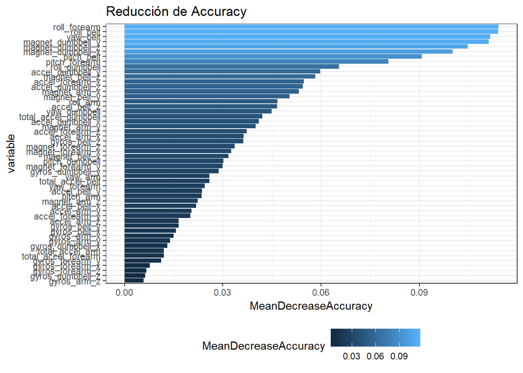

```r
ggplot(data = importancia, aes(x = reorder(variable, MeanDecreaseAccuracy),
                               y = MeanDecreaseAccuracy,
                               fill = MeanDecreaseAccuracy)) +
      labs(x = "variable", title = "Reducción de Accuracy") +
      geom_col() +
      coord_flip() +
      theme_bw() +
      theme(legend.position = "bottom")
```

##### Graph to evaluate the purity reduction

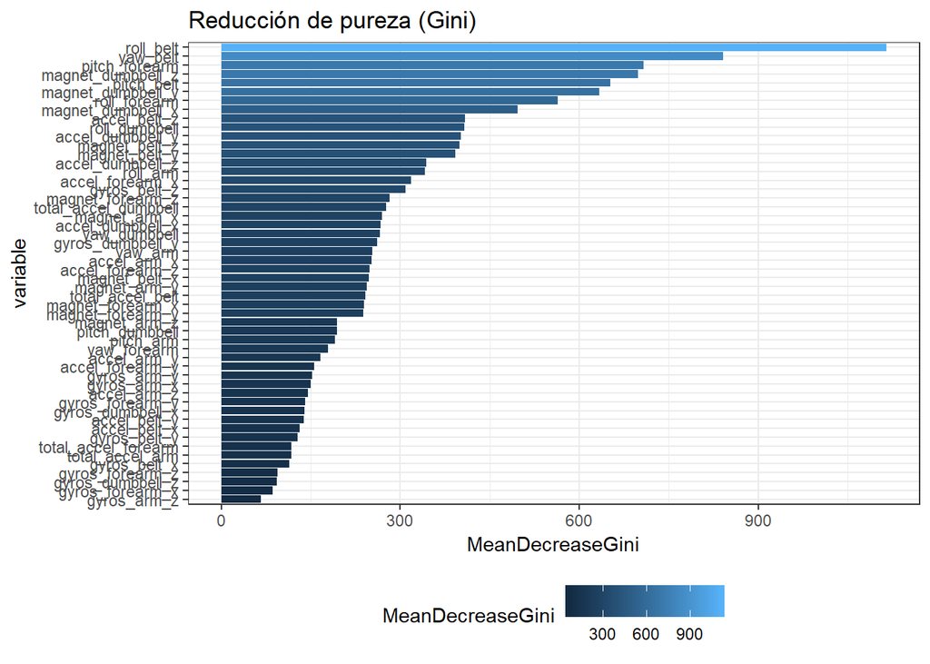

```r
ggplot(data = importancia, aes(x = reorder(variable, MeanDecreaseGini),
                               y = MeanDecreaseGini,
                               fill = MeanDecreaseGini)) +
      labs(x = "variable", title = "Reducción de pureza (Gini)") +
      geom_col() +
      coord_flip() +
      theme_bw() +
      theme(legend.position = "bottom")
```

Both analyzes suggest that the roll_belt and yaw_belt variables have a high influence on classe distribution.

### Variables with variance close to zero

Predictors that contain a single value (zero-variance) should not be included in the model since they do not provide information

```r
training %>% select(roll_belt, pitch_belt, yaw_belt, total_accel_belt, gyros_belt_x,
gyros_belt_y, gyros_belt_z, accel_belt_x, accel_belt_y, accel_belt_z, magnet_belt_x,
magnet_belt_y, magnet_belt_z, roll_arm, pitch_arm, yaw_arm, total_accel_arm, gyros_arm_x,
gyros_arm_y, gyros_arm_z, accel_arm_x, accel_arm_y, accel_arm_z, magnet_arm_x,
magnet_arm_y, magnet_arm_z, roll_dumbbell, pitch_dumbbell, yaw_dumbbell, total_accel_dumbbell,
gyros_dumbbell_x, gyros_dumbbell_y, gyros_dumbbell_z, accel_dumbbell_x, accel_dumbbell_y,
accel_dumbbell_z, magnet_dumbbell_x, magnet_dumbbell_y, magnet_dumbbell_z, roll_forearm,
pitch_forearm, yaw_forearm, total_accel_forearm, gyros_forearm_x, gyros_forearm_y,
gyros_forearm_z, accel_forearm_x, accel_forearm_y, accel_forearm_z, magnet_forearm_x,
magnet_forearm_y, magnet_forearm_z, classe) %>%
nearZeroVar(saveMetrics = TRUE)
```

[output not shown]

## Division of data in training and test

```r
train <- createDataPartition(y = training$classe, p = 0.8, list = FALSE, times = 1)
data_train <- training[train, ]
data_test  <- training[-train, ]
```

## Predictors selection

The wrapper methods evaluate multiple models, generated by the incorporation or elimination of predictors, in order to identify the optimal combination that maximizes the capacity of the model.

```r
library(doMC)
registerDoMC(cores = 4)

partitions = 10
repetitions = 5

set.seed(123)
seeds <- sample.int(1000, partitions * repetitions + 1)
```

#### Filter control

```r
ctrl_filtrado <- sbfControl(functions = rfSBF, method = "repeatedcv",
                            number = partitions, repeats = repetitions,
                            seeds = seeds, verbose = FALSE,
                            saveDetails = TRUE, allowParallel = TRUE)
set.seed(234)

rf_sbf <- sbf(classe ~ ., data = data_train,
              sbfControl = ctrl_filtrado,
               ntree = 500)

rf_sbf
rf_sbf$optVariables

predictors_filtered <- rf_sbf$optVariables
```

### Selection of the best predictors

```r
data_train_proce<- select(data_train,predictors_filtered,classe)
data_test_proce<- select(data_test,predictors_filtered,classe)
```

## Training of different models

In the following sections different machine learning models are trained in order to compare them and identify the best result obtained

### K-Nearest Neighbor (kNN)

```r
knn_model <- train(classe ~ ., data = data_train_proce,
                    method = "knn",
                    metric = "Accuracy")
```

### Naive Bayes

```r
nb_model <- train(classe ~ ., data = data_train_proce,
                   method = "nb",
                   metric = "Accuracy")
```

### Análisis discriminante lineal (LDA)

```r
lda_model <- train(classe ~ ., data = data_train_proce,
                    method = "lda",
                    metric = "Accuracy")
```

### C5.0 Decision Trees and Rule-Based Model

```r
C50Tree_model <- train(classe ~ ., data = data_train_proce,
                    method = "C5.0Tree",
                    metric = "Accuracy")
```

### RandomForest

```r
rf_model <- train(classe ~ ., data = data_train_proce,
                   method = "ranger",
                   metric = "Accuracy",
                   num.trees = 500)
```

## Model comparison, Validation metrics

Once different models have been trained and optimized, one must identify which of them achieves the best results for the problem, in this case, predict the classe of each patient.

```r
models <- list(KNN = knn_model, NB = nb_model, LDA = lda_model,
                tree = C50Tree_model, rf = rf_model)

outcome_resamples <- resamples(models)
outcome_resamples$values %>% head(10)
```

The data frame returned by resamples () is transformed to separate the name of the model and the metrics in different columns

```r
metrics_resamples <- outcome_resamples$values %>%
                         gather(key = "model", value = "valor", -Resample) %>%
                         separate(col = "model", into = c("model", "metric"),
                                  sep = "~", remove = TRUE)
metrics_resamples %>% head()
```

## Average Accuracy and Kappa of each model

```r
  metrics_resamples %>%
  group_by(model, metric) %>%
  summarise(media = mean(valor)) %>%
  spread(key = metric, value = media) %>%
  arrange(desc(Accuracy))
```

[output not shown]

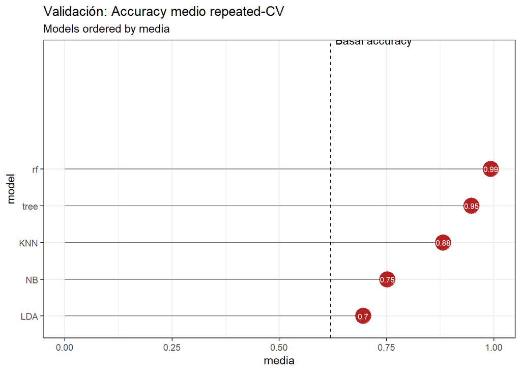

```r
metrics_resamples %>%
  filter(metric == "Accuracy") %>%
  group_by(model) %>%
  summarise(media = mean(valor)) %>%
  ggplot(aes(x = reorder(model, media), y = media, label = round(media, 2))) +
    geom_segment(aes(x = reorder(model, media), y = 0,
                     xend = model, yend = media),
                     color = "grey50") +
    geom_point(size = 7, color = "firebrick") +
    geom_text(color = "white", size = 2.5) +
    scale_y_continuous(limits = c(0, 1)) +
    geom_hline(yintercept = 0.62, linetype = "dashed") +
    annotate(geom = "text", y = 0.72, x = 8.5, label = "Basal accuracy") +
    labs(title = "Validación: Accuracy medio repeated-CV",
         subtitle = "Models ordered by media",
         x = "model") +
    coord_flip() +
    theme_bw()
```

## Conclusion

The model based on random forest is the one that obtains the best results (according to the accuracy metric)